# Final Project

2023-11-30

The name of the GitHub Repository is FinalProject-Group1 and the link to it can be found [here](https://github.com/R-4-Data-Science/FinalProject_Group1.git)

The name of the package itself is FinalProjectGroup1

To download the package, type the following into your console: devtools::install_github(“R-4-Data-Science/FinalProject_Group1/FinalProjectGroup1”)

#### *Beta Loss Function to Prepare For Logistic Regression Function*

```r
pf <- function(x, beta){
  out <- 1/(1 + exp(-t(x)%*%beta))
  return(out)
}


beta_ls <- function(beta, x, y){
  sum <- 0
  for(i in 1:nrow(x)){
    xi <- as.matrix(unlist(x[i,]), ncol = 1) #format it so dimensions work out later
    yi <- y[i]
    pi <- pf(xi,as.matrix(beta))

    res <- (-1*yi)*(log(pi)) - (1 - yi)*log(1-pi)
    sum <- sum + res
  }
  return(sum)

}
```

## *Logistic Regression with Optimization Function*

The parameters for this function should be a matrix of predictors with the first column being 1s to account for the intercept, and a vector for the response variable. The output produces a list consisting of the estimated coefficients (named “betas”), the predicted y-values using the estimated coefficientes (named “y_pred”), the initial y-values (named “y_actual”), and the initial X matrix (named “X”).

```r
log_reg <- function(X, y){
  colnames(X)[1] <- "Intercept"
  B_initial <- solve(t(X)%*%X)%*%t(X)%*%y
  result <- optim(par = B_initial, fn = beta_ls, x = X, y = y)
  parameters <- result$par
  y_pred <- X%*%parameters
  out <- list("betas" = parameters, "y_pred" = y_pred, "y_actual" = y, "X" = X)
  class(out) <- "my_b"

  return(out)

}
```

Example using Abalone Data set The response variable is the sex, male denoted as 1 and female denoted with 0. The predictors used are length, diameter, height, whole weight, shucked weight, viscera weight, shell weight and rings. The output from the log_reg function returns a list with the estimated beta coefficients for each of the predictors, including the intercept, the predicted sex, the actual sex, and the initial matrix of predictors.

```r
results <- log_reg(X_abalone, y_abalone)
results$betas
```

```
##                       [,1]
## Intercept       5.84528997
## Length         -6.43518617
## Diameter       -7.30567017
## Height         -4.61394726
## Whole_weight   -4.41317160
## Shucked_weight  8.36326158
## Viscera_weight -0.48689639
## Shell_weight   11.60462350
## Rings          -0.06840865
```

```r
head(results$y_pred)
```

```
##         [,1]
## 1  1.3885399
## 2 -0.3467664
## 3  0.3547053
## 6 -0.3459950
## 7 -0.4241839
## 8  0.3151795
```

```r
head(results$y_actual)
```

```
## [1] 1 0 1 0 0 1
```

```r
head(results$X)
```

```
##   Intercept Length Diameter Height Whole_weight Shucked_weight Viscera_weight
## 1         1  0.350    0.265  0.090       0.2255         0.0995         0.0485
## 2         1  0.530    0.420  0.135       0.6770         0.2565         0.1415
## 3         1  0.440    0.365  0.125       0.5160         0.2155         0.1140
## 6         1  0.530    0.415  0.150       0.7775         0.2370         0.1415
## 7         1  0.545    0.425  0.125       0.7680         0.2940         0.1495
## 8         1  0.475    0.370  0.125       0.5095         0.2165         0.1125
##   Shell_weight Rings
## 1        0.070     7
## 2        0.210     9
## 3        0.155    10
## 6        0.330    20
## 7        0.260    16
## 8        0.165     9
```

### *Plot of the Fitted Logistic Curve to the Responses*

The y-axis is the binary response observed y while the x-axis represents a sequence of values from the range of Xβ̂, or the predicted y value. This function uses the output from the log_reg function. To plot the results from the log_reg function, save the results from the function in an object and plot the object using plot(name of object)

```r
plot.my_b <- function(obj){
  y_pred <- obj$y_pred
  y_actual <- obj$y_actual
  X <- obj$X
  parameters <- obj$parameters

  plot(y_actual ~ y_pred ,xlim = range(y_pred), ylim = range(-.05, 1.5))

  x_line <- seq(min(y_pred), max(y_pred), length = length(y_pred))
  y_line <- pf(t(X), obj$betas)
  lines(x_line, sort(y_line), col = "red", lty = 1, lwd = 2)
}
```

Here we show the use of the plot() function in this package, using the results from the Abalone data set.

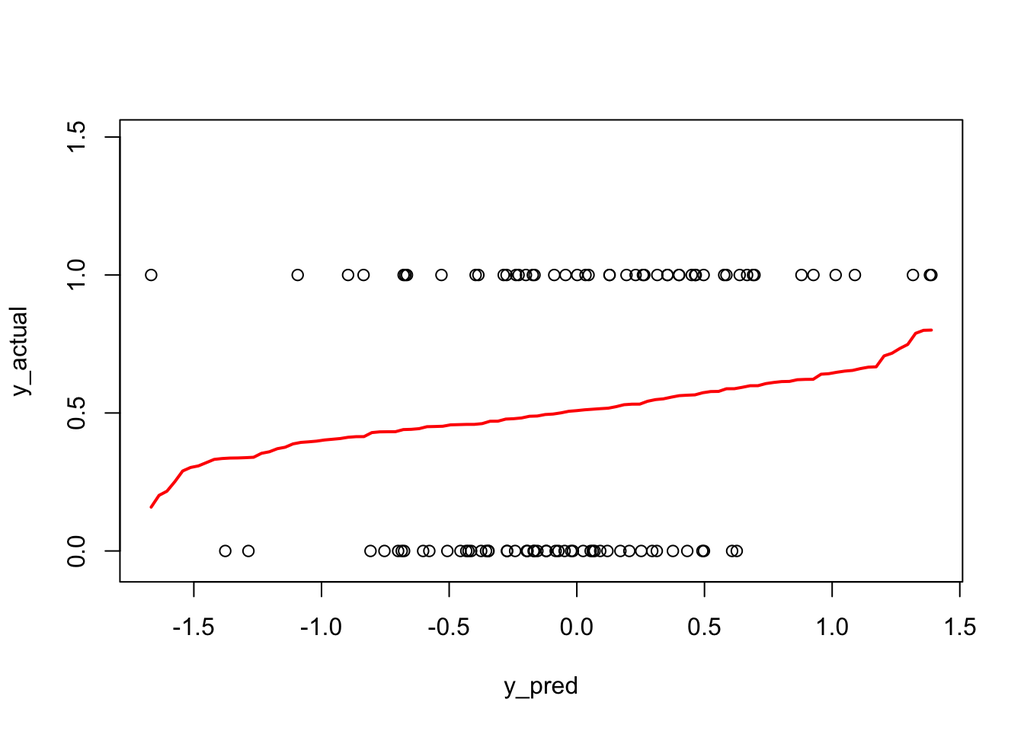

```r
plot(results)
```

### *Bootstrap Confidence intervals*

The user is able to choose (i) the significance level α to obtain for the 1−α confidence intervals for β, and (ii) the number of bootstraps which by default is 20. The parameters for this function include our matrix of predictors, a vector for the response variable, a level of significance (0.05 if not specified), and the number of bootstraps (20 if not specified). This function results in confidence intervals for each of the Beta coefficients.

```r
bootstrap_conf_intervals <- function(X, y, alpha = 0.05, n_bootstraps = 20) {
  n <- nrow(X)
  beta_bootstraps <- matrix(NA, ncol = n_bootstraps, nrow = length(log_reg(X, y)$betas))

  for (i in 1:n_bootstraps) {
    # Sample with replacement
    indices <- sample(1:n, replace = TRUE)
    X_bootstrap <- X[indices, ]
    y_bootstrap <- y[indices]

    # Run logistic regression on the bootstrap sample
    beta_bootstraps[, i] <- log_reg(X_bootstrap, y_bootstrap)$betas
  }

  # Calculate confidence intervals
  lower <- apply(beta_bootstraps, 1, function(row) quantile(row, alpha / 2))
  upper <- apply(beta_bootstraps, 1, function(row) quantile(row, 1 - alpha / 2))

  intervals <- data.frame(lower = lower, upper = upper)
  rownames(intervals) <- rownames(log_reg(X, y)$betas)
  return(intervals)
}
```

For example, using the Abalone dataset with different measurements as predictors:

```r
# Bootstrap confidence intervals
intervals <- bootstrap_conf_intervals(X_abalone, y_abalone)

# Print the resulting intervals
print(intervals)
```

```
##                      lower       upper
## Intercept       -2.5831882 10.32241482
## Length         -15.0713551 15.69026600
## Diameter       -21.1260987 19.21462307
## Height         -23.5374237 -1.45414690
## Whole_weight   -14.0426479  0.90961603
## Shucked_weight  -5.2518775 21.53625206
## Viscera_weight -13.1552806 12.29206804
## Shell_weight     2.5428913 29.04567297
## Rings           -0.2316906  0.07619153
```

### *Generate Resulting Confusion Matrix*

```r
library(caret)
confmat <- function(y_actual, y_pred, cutoff = 0.5){
  #convert predicted values to 0 or 1 based on threshold
  y_actual <- factor(y_actual)
  y_bin <- factor(ifelse(y_pred >= cutoff, 1,0), levels = levels(y_actual))
  cmat <- confusionMatrix(y_actual, y_bin)
  metrics <- cmat$byClass
  prevalence <- as.numeric(metrics["Prevalence"])
  accuracy <- as.numeric(cmat$overall["Accuracy"])
  sensitivity <- as.numeric(metrics["Sensitivity"])
  specificity <- as.numeric(metrics["Specificity"])
  true_p <- cmat$byClass["Pos Pred Value"] * cmat$byClass["Precision"]
  false_p <- cmat$byClass["Neg Pred Value"] * cmat$byClass["Precision"]
  false_discovery_rate <- as.numeric(false_p / (false_p + true_p))
  diagnostic_odds_ratio <- as.numeric(metrics["Sensitivity"]/(1 - metrics["Specificity"]))

  out <- invisible(list("Prevalence" = prevalence, "Accuracy" = accuracy, "Sensitivity" = sensitivity, "Specificity" = specificity, "False Discovery Rate" = false_discovery_rate, "Diagnostic Odds Ratio" = diagnostic_odds_ratio))
  return(out)

}
```

Here is an example of the output when running the confusion matrix function on the Abalone data set with a cutoff of 0.5. We can use the outputs from the log_reg function to use as the parameters for this function.

```r
y_p <- results$y_pred
y_a <- results$y_actual

test <- confmat(y_a, y_p)
test
```

```
## $Prevalence
## [1] 0.85
##
## $Accuracy
## [1] 0.61
##
## $Sensitivity
## [1] 0.5647059
##
## $Specificity
## [1] 0.8666667
##
## $`False Discovery Rate`
## [1] 0.2131148
##
## $`Diagnostic Odds Ratio`
## [1] 4.235294
```

### *Plot Above Metrics Over A Grid*

The possibility for the user to plot of any of the above metrics evaluated over a grid of cut-off values for prediction going from 0.1 to 0.9 with steps of 0.1.

```r
plot_metrics <- function(X, y, cutoff_values = seq(0.1, 0.9, by = 0.1)) {
  result <- log_reg(X, y)
  predicted_probs <- pf(t(X), result$betas)
  metrics_matrix <- matrix(NA, nrow = length(cutoff_values), ncol = 7,
                           dimnames = list(NULL, c("Cutoff", "Prevalence", "Accuracy", "Sensitivity", "Specificity", "False Discovery Rate", "Diagnostic Odds Ratio")))

  # Calculate metrics for each cutoff
  for (i in seq_along(cutoff_values)) {
    metrics <- confmat(y, predicted_probs, cutoff_values[i])
    metrics_matrix[i, ] <- c(cutoff_values[i], metrics[[1]], metrics[[2]], metrics[[3]], metrics[[4]], metrics[[5]], metrics[[6]])
  }

  # Plot metrics
  par(mfrow = c(3, 2), mar = c(4, 4, 2, 1), oma = c(0, 0, 2, 0))
  metrics_names <- c("Prevalence", "Accuracy", "Sensitivity", "Specificity", "False Discovery Rate", "Diagnostic Odds Ratio")
  for (i in seq_along(metrics_names)) {
    plot(metrics_matrix[, "Cutoff"], metrics_matrix[, i + 1], type = "l", col = i + 1,
         xlab = "Cutoff", ylab = metrics_names[i], main = paste("Metric vs. Cutoff"))

  }
}
```

Here is an example of this function being used with the above calculated metrics from the Abalone data set.

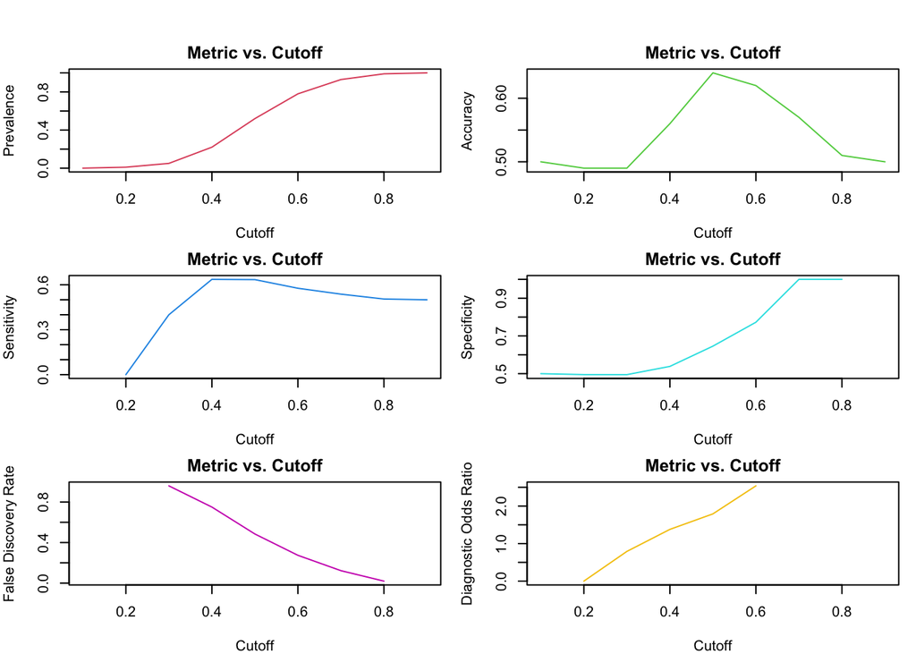

```r
plotmet <- plot_metrics(X_abalone, y_abalone)
```

Sources used on this package can be found [here](https://chat.openai.com/share/48ab81e0-3098-4583-a555-a07d2b50fed1)

Sources used on this package can be found [here](https://chat.openai.com/share/48ab81e0-3098-4583-a555-a07d2b50fed1), [here](https://chat.openai.com/share/70e25e13-a825-426e-b474-0d685d209583), and [here](https://chat.openai.com/share/4d4e8066-9a72-4eba-a268-dcbd26b2db62).